# Analysis

12/17/2020

## A tutorial for `my_rf_cv`

For this demonstration, we will use `my_rf_cv` function to predict `body_mass_g` using covariates `bill_length_mm`, `bill_depth_mm`, and `flipper_length_mm.`  
We will iterate through k as 2, 5 and 10:  
* For each value of k, run your function 30 times. * For each of the 30 iterations, store the CV estimated MSE.

```r
# load packages for this tutorial
library(ggplot2)
library(tidyverse)
library(class)
library(randomForest)

# Load Data
my_penguins <- read_csv("../Data/my_penguins.csv")
my_gapminder <- read_csv("../Data/my_gapminder.csv")

# Source code.
source("../Code/my_rf_cv.R")
```

```r
# store 30 CV estimated MSE when k = 2
mse_2 <- rep(NA, 30)
# store 30 CV estimated MSE when k = 2
mse_5 <- rep(NA, 30)
# store 30 CV estimated MSE when k = 2
mse_10 <- rep(NA, 30)
# For each k, run the function 30 times to generate 30 CV errors.
for (i in 1:30) {
  mse_2[i] <- my_rf_cv(2)
  mse_5[i] <- my_rf_cv(5)
  mse_10[i] <- my_rf_cv(10)
}

# mse table for k = 2
mse_2_df <- data.frame("k_value" = as.factor(rep(2, 30)), "cv_estimated_mse" = mse_2)
# mse table for k = 5
mse_5_df <- data.frame("k_value" = as.factor(rep(5, 30)), "cv_estimated_mse" = mse_5)
# mse table for k = 10
mse_10_df <- data.frame("k_value" = as.factor(rep(10, 30)), "cv_estimated_mse" = mse_10)

# combine all three dataframes
mse_df <- rbind(mse_2_df, mse_5_df, mse_10_df)

simulation_mse <- data_frame("k = 2" = as.vector(mse_2), "k = 5" = as.vector(mse_5), "k = 10" = as.vector(mse_10))

write_csv(simulation_mse, "../Output/Results/simulation_mse.csv")
```

Now, we will make 3 boxplots to display these data in an informative way. Each boxplot is associated with each value of $k$, representing 30 simulations.

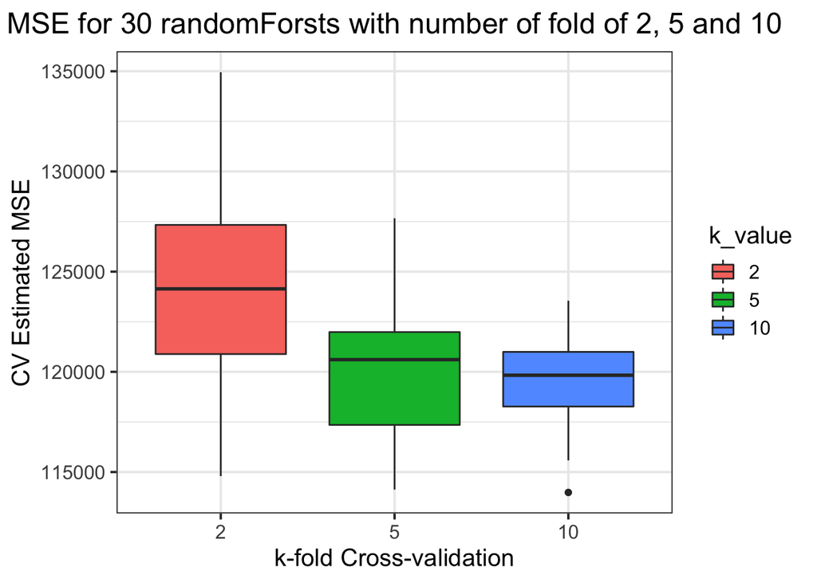

```r
# Make 3 boxplots.
ggplot(data = mse_df, aes(x = k_value, y = cv_estimated_mse, fill = k_value)) +
  geom_boxplot() +
  theme_bw(base_size = 15) +
  labs(title = "MSE for 30 randomForsts with number of fold of 2, 5 and 10",
       x = "k-fold Cross-validation",
       y = "CV Estimated MSE") +
  theme(plot.title = element_text(hjust = 0.5))
```

```r
ggsave("../Output/Figures/mse_boxplots.png")
```

```r
# calculate the mean and sd when k = 2
mse_2_mean <- mean(mse_2_df$cv_estimated_mse)
mse_2_sd <- sd(mse_2_df$cv_estimated_mse)

# calculate the mean and sd when k = 5
mse_5_mean <- mean(mse_5_df$cv_estimated_mse)
mse_5_sd <- sd(mse_5_df$cv_estimated_mse)

# calculate the mean and sd when k = 10
mse_10_mean <- mean(mse_10_df$cv_estimated_mse)
mse_10_sd <- sd(mse_10_df$cv_estimated_mse)

mse_table <- data.frame("k_value" = c(2, 5, 10),
                        "MSE_mean" = c(mse_2_mean, mse_5_mean, mse_10_mean),
                        "MSE_sd" = c(mse_2_sd, mse_5_sd, mse_10_sd))
mse_table
```

```
##   k_value MSE_mean   MSE_sd
## 1       2 124692.3 4753.989
## 2       5 120028.9 3301.588
## 3      10 119514.0 2074.237
```

```r
saveRDS(mse_table, "../Output/Results/mse_mean_sd_table.rds")
```

From the boxplots as well as the mse table, we can tell that the MSE mean and MSE standard deviation when k = 10 is lower than when k = 2 and k = 5. We can tell directly from the boxplots that as the value of k increase, the MSE mean and MSE sd decrease. The mse table shows that trends as well. This makes sense since when there are more folds, there will be higher accuracy, which would lead to less mean squared error.